* Encoding: UTF-8.  
EXAMINE VARIABLES=S1_R1 S1_R2 S2_R1 S2_R2  
/PLOT BOXPLOT NPPLOT  
/COMPARE GROUPS  
/STATISTICS NONE  
/CINTERVAL 95  
/MISSING LISTWISE  
/NOTOTAL.

# **Explore**

NotesNotes, table, 0 levels of column headers and 2 levels of row headers, table with 3 columns and 14 rows

| Output Created |  | 15-APR-2019 23:57:31 |
| --- | --- | --- |
| Comments |  |  |
| Input | Data | Z:\Documents\GitHub\STISIM-Task-Analysis\SPSS Results\Task_RT_wide_congruent.sav |
|  | Active Dataset | DataSet3 |
|  | Filter | <none> |
|  | Weight | <none> |
|  | Split File | <none> |
|  | N of Rows in Working Data File | 13 |
| Missing Value Handling | Definition of Missing | User-defined missing values for dependent variables are treated as missing. |
|  | Cases Used | Statistics are based on cases with no missing values for any dependent variable or factor used. |
| Syntax |  | EXAMINE VARIABLES=S1_R1 S1_R2 S2_R1 S2_R2 /PLOT BOXPLOT NPPLOT /COMPARE GROUPS /STATISTICS NONE /CINTERVAL 95 /MISSING LISTWISE /NOTOTAL. |
| Resources | Processor Time | 00:00:02.23 |
|  | Elapsed Time | 00:00:02.20 |

[DataSet3] Z:\Documents\GitHub\STISIM-Task-Analysis\SPSS Results\Task_RT_wide_congruent.sav

Case Processing SummaryCase Processing Summary, table, 3 levels of column headers and 1 levels of row headers, table with 7 columns and 8 rows

|  | Cases |  |  |  |  |  |
| --- | --- | --- | --- | --- | --- | --- |
|  | Valid |  | Missing |  | Total |  |
|  | N | Percent | N | Percent | N | Percent |
| S1_R1 | 12 | 92.3% | 1 | 7.7% | 13 | 100.0% |
| S1_R2 | 12 | 92.3% | 1 | 7.7% | 13 | 100.0% |
| S2_R1 | 12 | 92.3% | 1 | 7.7% | 13 | 100.0% |
| S2_R2 | 12 | 92.3% | 1 | 7.7% | 13 | 100.0% |

Tests of NormalityTests of Normality, table, 2 levels of column headers and 1 levels of row headers, table with 7 columns and 9 rows

|  | Kolmogorov-Smirnov<sup>a</sup> |  |  | Shapiro-Wilk |  |  |
| --- | --- | --- | --- | --- | --- | --- |
|  | Statistic | df | Sig. | Statistic | df | Sig. |
| S1_R1 | .144 | 12 | .200* | .954 | 12 | .690 |
| S1_R2 | .167 | 12 | .200* | .955 | 12 | .714 |
| S2_R1 | .211 | 12 | .145 | .905 | 12 | .185 |
| S2_R2 | .257 | 12 | .028 | .867 | 12 | .060 |

*. This is a lower bound of the true significance.  
a. Lilliefors Significance Correction

# **S1_R1**

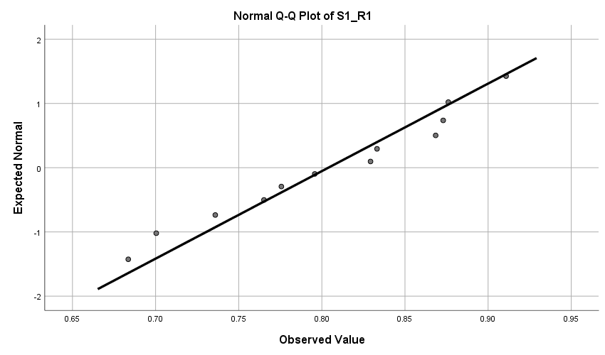

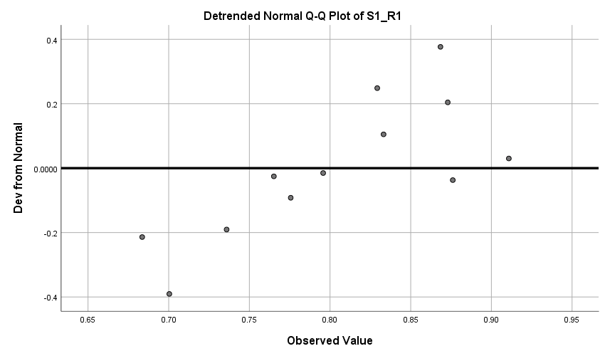

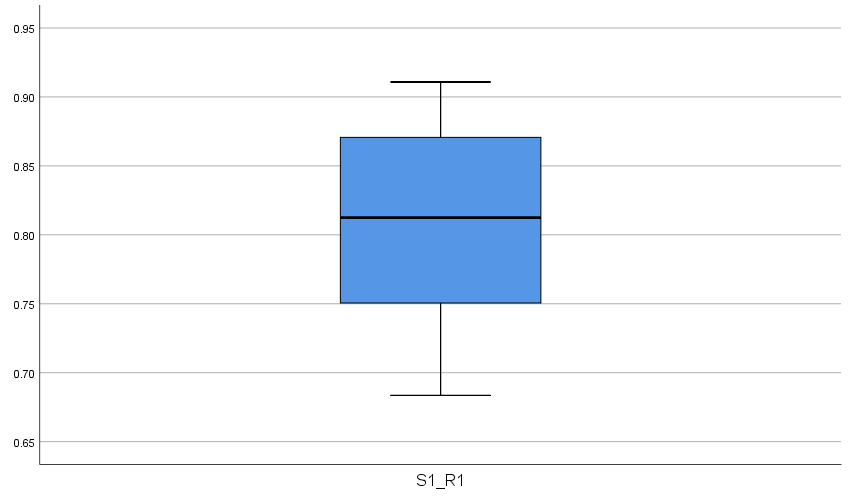

# **S1_R2**

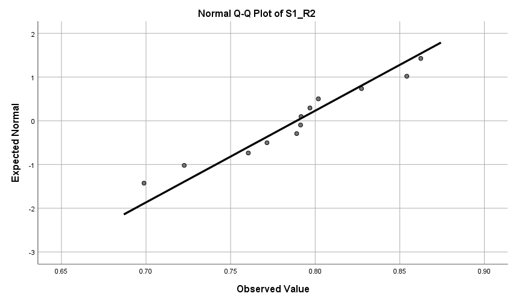

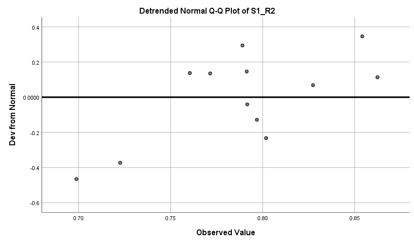

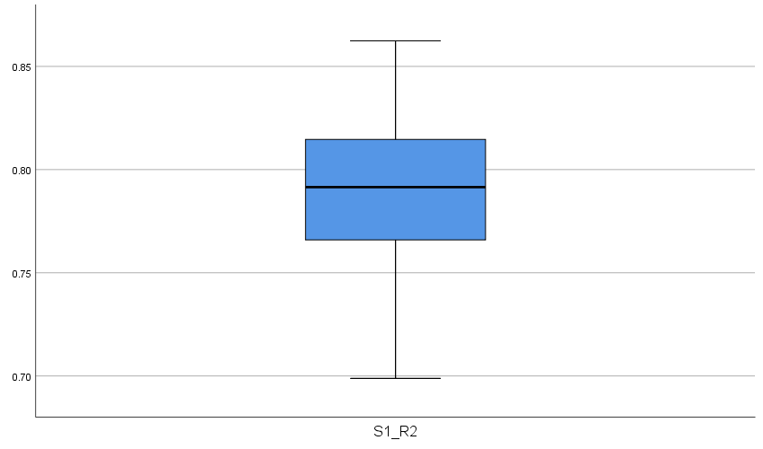

# **S2_R1**

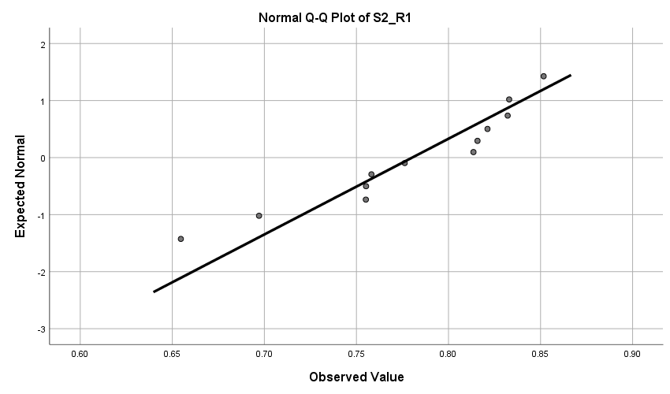

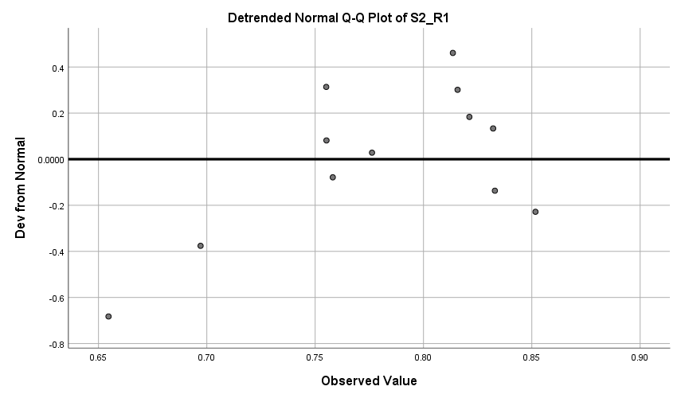

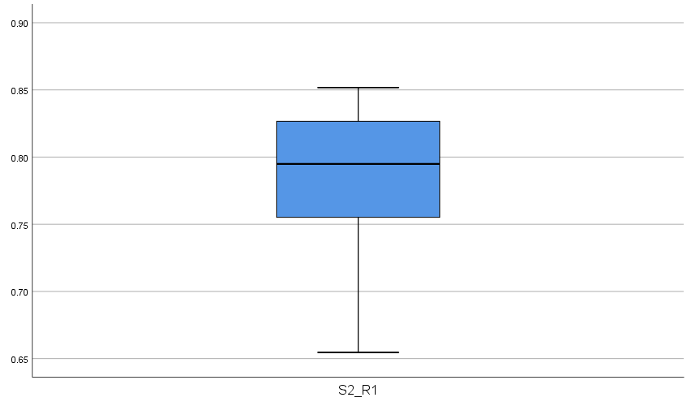

# **S2_R2**

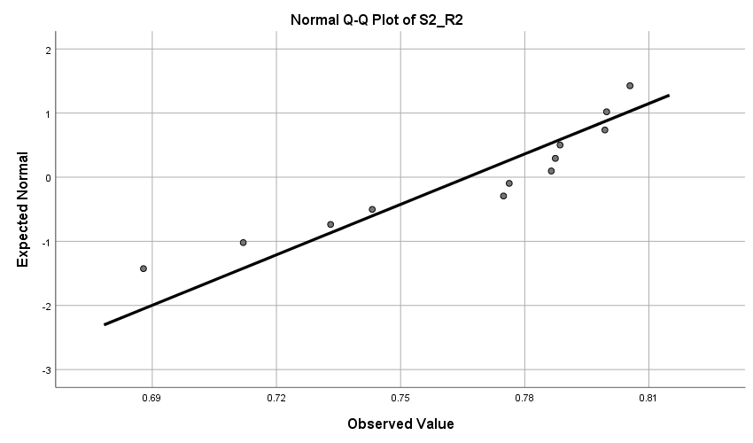

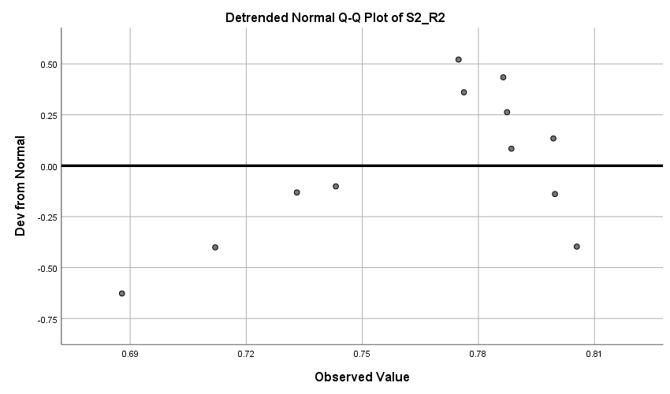

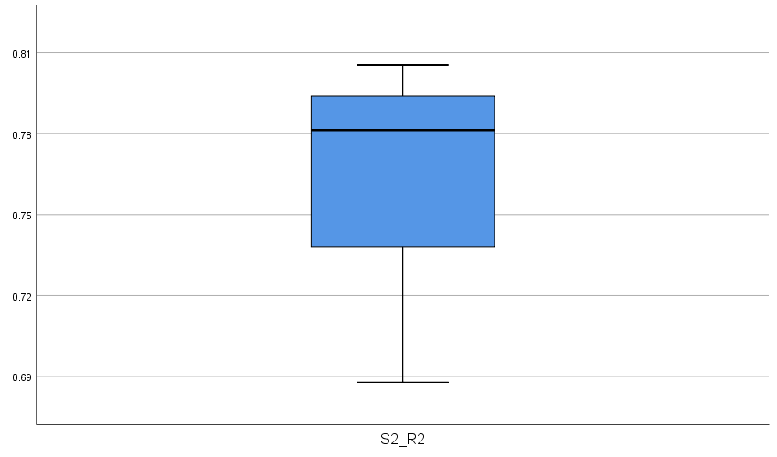

T-TEST PAIRS=S1_R1 S2_R1 S1_R2 WITH S1_R2 S2_R2 S2_R2 (PAIRED)  
/CRITERIA=CI(.9500)  
/MISSING=ANALYSIS.

# **T-Test**

NotesNotes, table, 0 levels of column headers and 2 levels of row headers, table with 3 columns and 14 rows

| Output Created |  | 15-APR-2019 23:57:33 |
| --- | --- | --- |
| Comments |  |  |
| Input | Data | Z:\Documents\GitHub\STISIM-Task-Analysis\SPSS Results\Task_RT_wide_congruent.sav |
|  | Active Dataset | DataSet3 |
|  | Filter | <none> |
|  | Weight | <none> |
|  | Split File | <none> |
|  | N of Rows in Working Data File | 13 |
| Missing Value Handling | Definition of Missing | User defined missing values are treated as missing. |
|  | Cases Used | Statistics for each analysis are based on the cases with no missing or out-of-range data for any variable in the analysis. |
| Syntax |  | T-TEST PAIRS=S1_R1 S2_R1 S1_R2 WITH S1_R2 S2_R2 S2_R2 (PAIRED) /CRITERIA=CI(.9500) /MISSING=ANALYSIS. |
| Resources | Processor Time | 00:00:00.03 |
|  | Elapsed Time | 00:00:00.06 |

Paired Samples StatisticsPaired Samples Statistics, table, 1 levels of column headers and 2 levels of row headers, table with 6 columns and 8 rows

|  |  | Mean | N | Std. Deviation | Std. Error Mean |
| --- | --- | --- | --- | --- | --- |
| Pair 1 | S1_R1 | .809034 | 13 | .0726444 | .0201479 |
|  | S1_R2 | .794091 | 13 | .0492121 | .0136490 |
| Pair 2 | S2_R1 | .780305 | 12 | .0596013 | .0172054 |
|  | S2_R2 | .766175 | 12 | .0381412 | .0110104 |
| Pair 3 | S1_R2 | .794091 | 13 | .0492121 | .0136490 |
|  | S2_R2 | .769692 | 13 | .0386567 | .0107214 |

Paired Samples CorrelationsPaired Samples Correlations, table, 1 levels of column headers and 2 levels of row headers, table with 5 columns and 5 rows

|  |  | N | Correlation | Sig. |
| --- | --- | --- | --- | --- |
| Pair 1 | S1_R1 & S1_R2 | 13 | .859 | .000 |
| Pair 2 | S2_R1 & S2_R2 | 12 | .937 | .000 |
| Pair 3 | S1_R2 & S2_R2 | 13 | .903 | .000 |

Paired Samples TestPaired Samples Test, table, 3 levels of column headers and 2 levels of row headers, table with 10 columns and 7 rows

|  |  | Paired Differences |  |  |  |  | t | df | Sig. (2-tailed) |  |  |  |
| --- | --- | --- | --- | --- | --- | --- | --- | --- | --- | --- | --- | --- |
|  |  | Mean | Std. Deviation | Std. Error Mean | 95% Confidence Interval of the Difference |  |  |  |  |  |  |  |
|  |  |  |  |  | Lower | Upper |  |  |  |  |  |  |
| Pair 1 | S1_R1 - S1_R2 | .0149420 | .0394395 | .0109386 | -.0088910 | .0387751 |  |  |  | 1.366 | 12 | .197 |
| Pair 2 | S2_R1 - S2_R2 | .0141305 | .0273461 | .0078941 | -.0032444 | .0315054 |  |  |  | 1.790 | 11 | .101 |
| Pair 3 | S1_R2 - S2_R2 | .0243996 | .0219002 | .0060740 | .0111655 | .0376337 | 4.017 | 12 | .002 |  |  |  |

COMPUTE logS1_R1=LG10(S1_R1).  
EXECUTE.  
COMPUTE logS1_R2=LG10(S1_R2).  
EXECUTE.  
COMPUTE logS2_R1=LG10(S2_R1).  
EXECUTE.  
COMPUTE logS2_R2=LG10(S2_R2).  
EXECUTE.  
EXAMINE VARIABLES=logS1_R1 logS1_R2 logS2_R1 logS2_R2  
/PLOT NPPLOT  
/STATISTICS NONE  
/CINTERVAL 95  
/MISSING LISTWISE  
/NOTOTAL.

# **Explore**

NotesNotes, table, 0 levels of column headers and 2 levels of row headers, table with 3 columns and 14 rows

| Output Created |  | 15-APR-2019 23:57:34 |
| --- | --- | --- |
| Comments |  |  |
| Input | Data | Z:\Documents\GitHub\STISIM-Task-Analysis\SPSS Results\Task_RT_wide_congruent.sav |
|  | Active Dataset | DataSet3 |
|  | Filter | <none> |
|  | Weight | <none> |
|  | Split File | <none> |
|  | N of Rows in Working Data File | 13 |
| Missing Value Handling | Definition of Missing | User-defined missing values for dependent variables are treated as missing. |
|  | Cases Used | Statistics are based on cases with no missing values for any dependent variable or factor used. |
| Syntax |  | EXAMINE VARIABLES=logS1_R1 logS1_R2 logS2_R1 logS2_R2 /PLOT NPPLOT /STATISTICS NONE /CINTERVAL 95 /MISSING LISTWISE /NOTOTAL. |
| Resources | Processor Time | 00:00:01.53 |
|  | Elapsed Time | 00:00:01.48 |

Case Processing SummaryCase Processing Summary, table, 3 levels of column headers and 1 levels of row headers, table with 7 columns and 8 rows

|  | Cases |  |  |  |  |  |
| --- | --- | --- | --- | --- | --- | --- |
|  | Valid |  | Missing |  | Total |  |
|  | N | Percent | N | Percent | N | Percent |
| logS1_R1 | 12 | 92.3% | 1 | 7.7% | 13 | 100.0% |
| logS1_R2 | 12 | 92.3% | 1 | 7.7% | 13 | 100.0% |
| logS2_R1 | 12 | 92.3% | 1 | 7.7% | 13 | 100.0% |
| logS2_R2 | 12 | 92.3% | 1 | 7.7% | 13 | 100.0% |

Tests of NormalityTests of Normality, table, 2 levels of column headers and 1 levels of row headers, table with 7 columns and 9 rows

|  | Kolmogorov-Smirnov<sup>a</sup> |  |  | Shapiro-Wilk |  |  |
| --- | --- | --- | --- | --- | --- | --- |
|  | Statistic | df | Sig. | Statistic | df | Sig. |
| logS1_R1 | .147 | 12 | .200* | .947 | 12 | .601 |
| logS1_R2 | .178 | 12 | .200* | .949 | 12 | .628 |
| logS2_R1 | .213 | 12 | .138 | .890 | 12 | .118 |
| logS2_R2 | .263 | 12 | .021 | .859 | 12 | .048 |

*. This is a lower bound of the true significance.  
a. Lilliefors Significance Correction

# **logS1_R1**

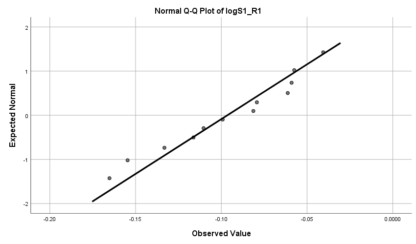

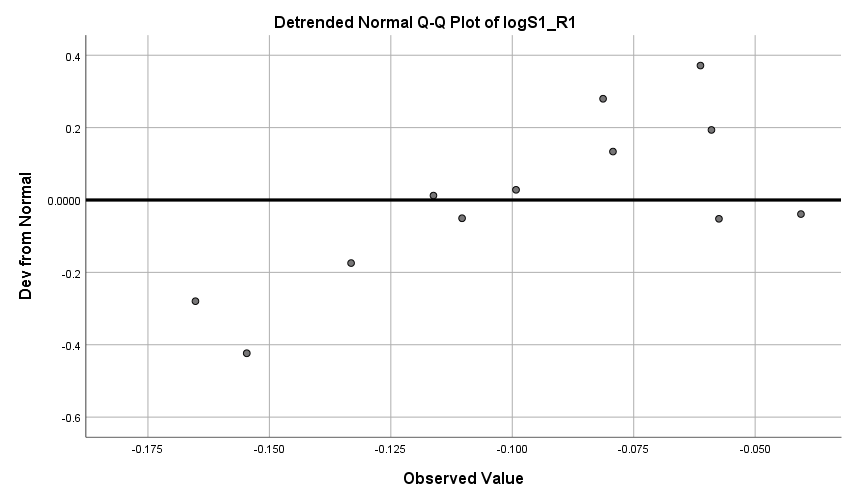

# **logS1_R2**

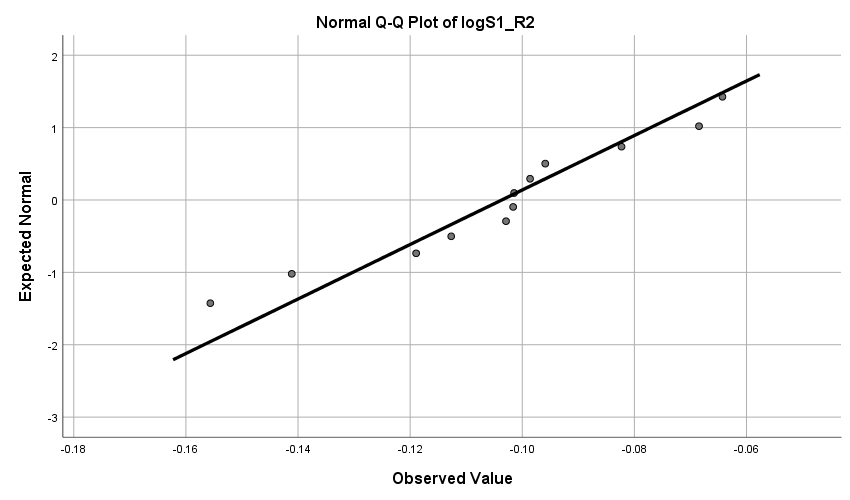

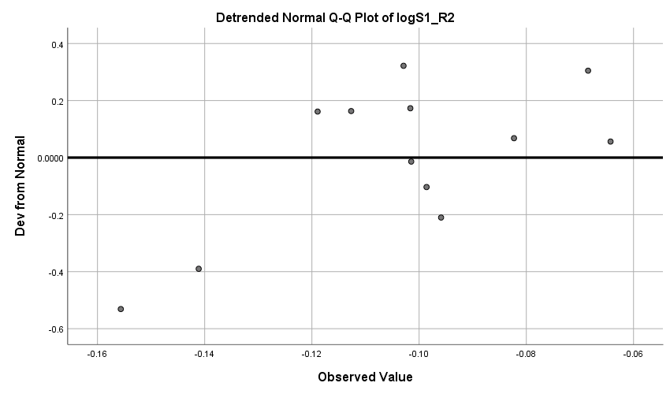

# **logS2_R1**

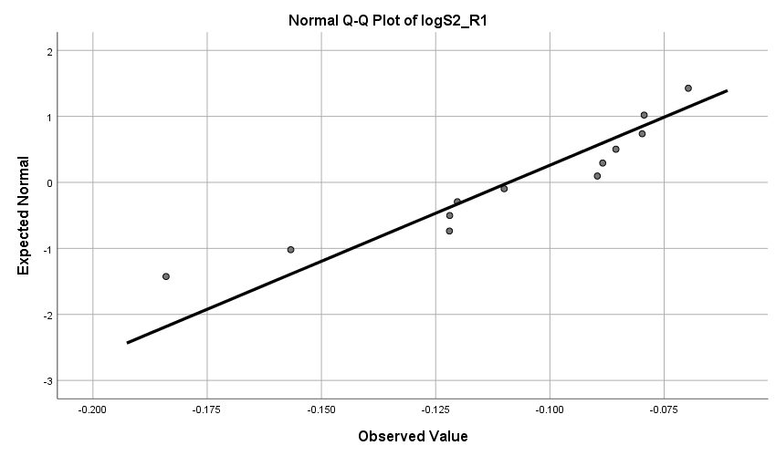

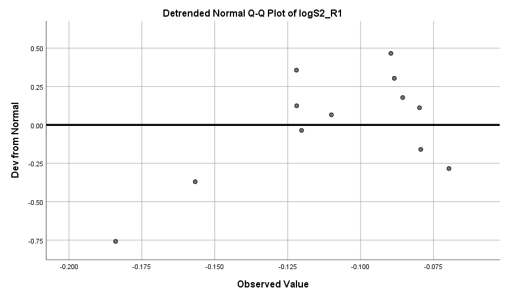

# **logS2_R2**

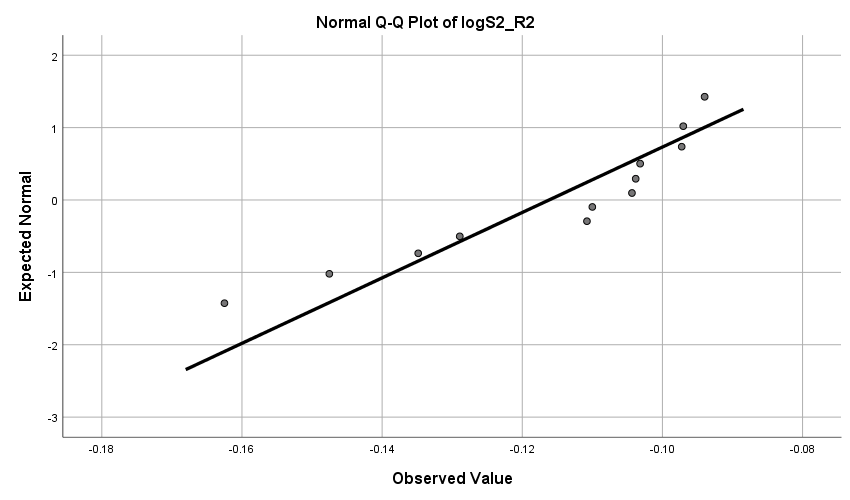

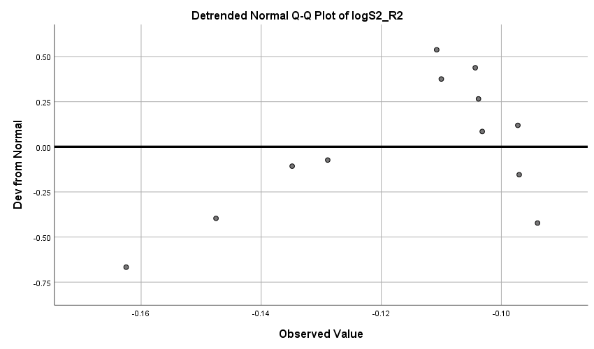

T-TEST PAIRS=logS1_R1 logS2_R1 logS1_R2 WITH logS1_R2 logS2_R2 logS2_R2 (PAIRED)  
/CRITERIA=CI(.9500)  
/MISSING=ANALYSIS.

# **T-Test**

NotesNotes, table, 0 levels of column headers and 2 levels of row headers, table with 3 columns and 14 rows

| Output Created |  | 15-APR-2019 23:57:35 |
| --- | --- | --- |
| Comments |  |  |
| Input | Data | Z:\Documents\GitHub\STISIM-Task-Analysis\SPSS Results\Task_RT_wide_congruent.sav |
|  | Active Dataset | DataSet3 |
|  | Filter | <none> |
|  | Weight | <none> |
|  | Split File | <none> |
|  | N of Rows in Working Data File | 13 |
| Missing Value Handling | Definition of Missing | User defined missing values are treated as missing. |
|  | Cases Used | Statistics for each analysis are based on the cases with no missing or out-of-range data for any variable in the analysis. |
| Syntax |  | T-TEST PAIRS=logS1_R1 logS2_R1 logS1_R2 WITH logS1_R2 logS2_R2 logS2_R2 (PAIRED) /CRITERIA=CI(.9500) /MISSING=ANALYSIS. |
| Resources | Processor Time | 00:00:00.00 |
|  | Elapsed Time | 00:00:00.00 |

Paired Samples StatisticsPaired Samples Statistics, table, 1 levels of column headers and 2 levels of row headers, table with 6 columns and 8 rows

|  |  | Mean | N | Std. Deviation | Std. Error Mean |
| --- | --- | --- | --- | --- | --- |
| Pair 1 | logS1_R1 | -.0937 | 13 | .03987 | .01106 |
|  | logS1_R2 | -.1009 | 13 | .02729 | .00757 |
| Pair 2 | logS2_R1 | -.1090 | 12 | .03436 | .00992 |
|  | logS2_R2 | -.1162 | 12 | .02213 | .00639 |
| Pair 3 | logS1_R2 | -.1009 | 13 | .02729 | .00757 |
|  | logS2_R2 | -.1142 | 13 | .02235 | .00620 |

Paired Samples CorrelationsPaired Samples Correlations, table, 1 levels of column headers and 2 levels of row headers, table with 5 columns and 5 rows

|  |  | N | Correlation | Sig. |
| --- | --- | --- | --- | --- |
| Pair 1 | logS1_R1 & logS1_R2 | 13 | .872 | .000 |
| Pair 2 | logS2_R1 & logS2_R2 | 12 | .942 | .000 |
| Pair 3 | logS1_R2 & logS2_R2 | 13 | .912 | .000 |

Paired Samples TestPaired Samples Test, table, 3 levels of column headers and 2 levels of row headers, table with 10 columns and 7 rows

|  |  | Paired Differences |  |  |  |  | t | df | Sig. (2-tailed) |  |  |  |
| --- | --- | --- | --- | --- | --- | --- | --- | --- | --- | --- | --- | --- |
|  |  | Mean | Std. Deviation | Std. Error Mean | 95% Confidence Interval of the Difference |  |  |  |  |  |  |  |
|  |  |  |  |  | Lower | Upper |  |  |  |  |  |  |
| Pair 1 | logS1_R1 - logS1_R2 | .00722 | .02090 | .00580 | -.00542 | .01985 |  |  |  | 1.245 | 12 | .237 |
| Pair 2 | logS2_R1 - logS2_R2 | .00723 | .01544 | .00446 | -.00258 | .01704 |  |  |  | 1.621 | 11 | .133 |
| Pair 3 | logS1_R2 - logS2_R2 | .01329 | .01147 | .00318 | .00636 | .02022 | 4.178 | 12 | .001 |  |  |  |

*Nonparametric Tests: Related Samples.  
NPTESTS  
/RELATED TEST(S1_R1 S1_R2) WILCOXON  
/MISSING SCOPE=ANALYSIS USERMISSING=EXCLUDE  
/CRITERIA ALPHA=0.05 CILEVEL=95.

# **Nonparametric Tests**

NotesNotes, table, 0 levels of column headers and 2 levels of row headers, table with 3 columns and 12 rows

| Output Created |  | 15-APR-2019 23:57:35 |
| --- | --- | --- |
| Comments |  |  |
| Input | Data | Z:\Documents\GitHub\STISIM-Task-Analysis\SPSS Results\Task_RT_wide_congruent.sav |
|  | Active Dataset | DataSet3 |
|  | Filter | <none> |
|  | Weight | <none> |
|  | Split File | <none> |
|  | N of Rows in Working Data File | 13 |
| Syntax |  | NPTESTS /RELATED TEST(S1_R1 S1_R2) WILCOXON /MISSING SCOPE=ANALYSIS USERMISSING=EXCLUDE /CRITERIA ALPHA=0.05 CILEVEL=95. |
| Resources | Processor Time | 00:00:00.13 |
|  | Elapsed Time | 00:00:00.09 |

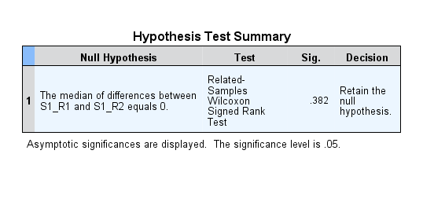

*Nonparametric Tests: Related Samples.  
NPTESTS  
/RELATED TEST(S2_R1 S2_R2) WILCOXON  
/MISSING SCOPE=ANALYSIS USERMISSING=EXCLUDE  
/CRITERIA ALPHA=0.05 CILEVEL=95.

# **Nonparametric Tests**

NotesNotes, table, 0 levels of column headers and 2 levels of row headers, table with 3 columns and 12 rows

| Output Created |  | 15-APR-2019 23:57:35 |
| --- | --- | --- |
| Comments |  |  |
| Input | Data | Z:\Documents\GitHub\STISIM-Task-Analysis\SPSS Results\Task_RT_wide_congruent.sav |
|  | Active Dataset | DataSet3 |
|  | Filter | <none> |
|  | Weight | <none> |
|  | Split File | <none> |
|  | N of Rows in Working Data File | 13 |
| Syntax |  | NPTESTS /RELATED TEST(S2_R1 S2_R2) WILCOXON /MISSING SCOPE=ANALYSIS USERMISSING=EXCLUDE /CRITERIA ALPHA=0.05 CILEVEL=95. |
| Resources | Processor Time | 00:00:00.11 |
|  | Elapsed Time | 00:00:00.09 |

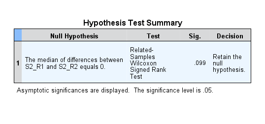

*Nonparametric Tests: Related Samples.  
NPTESTS  
/RELATED TEST(S1_R2 S2_R2) WILCOXON  
/MISSING SCOPE=ANALYSIS USERMISSING=EXCLUDE  
/CRITERIA ALPHA=0.05 CILEVEL=95.

# **Nonparametric Tests**

NotesNotes, table, 0 levels of column headers and 2 levels of row headers, table with 3 columns and 12 rows

| Output Created |  | 15-APR-2019 23:57:35 |
| --- | --- | --- |
| Comments |  |  |
| Input | Data | Z:\Documents\GitHub\STISIM-Task-Analysis\SPSS Results\Task_RT_wide_congruent.sav |
|  | Active Dataset | DataSet3 |
|  | Filter | <none> |
|  | Weight | <none> |
|  | Split File | <none> |
|  | N of Rows in Working Data File | 13 |
| Syntax |  | NPTESTS /RELATED TEST(S1_R2 S2_R2) WILCOXON /MISSING SCOPE=ANALYSIS USERMISSING=EXCLUDE /CRITERIA ALPHA=0.05 CILEVEL=95. |
| Resources | Processor Time | 00:00:00.13 |
|  | Elapsed Time | 00:00:00.09 |

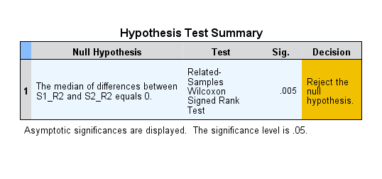